# Padovese Pietro Statistical Learning Exam

2023-11-05

# **1) Description of Variables**

- **AcceptedCmp1**: 1 if costumer accepted the offer in the first campaign, 0 otherwise
- **AcceptedCmp2**: 1 if costumer accepted the offer in the second campaign, 0 otherwise
- **AcceptedCmp3**: 1 if costumer accepted the offer in the third campaign, 0 otherwise
- **AcceptedCmp4**: 1 if costumer accepted the offer in the fourth campaign, 0 otherwise
- **AcceptedCmp5**: 1 if costumer accepted the offer in the fifth campaign, 0 otherwise
- **AcceptedCmpOverall (target)**: 1 if costumer accepted the offer in the last campaign, 0 otherwise
- **Complain**: 1 if customer complained in the last 2 years
- **DtCustomer**: date of customer’s enrollment with the company
- **Education**: customer’s level of education
- **Marital**: customer’s marital status
- **Kidhome**: number of small children in customer’s household
- **Teenhome**: number of teenagers in customerìs household
- **Income**: customer’s yearly household income
- **MntFishProducts**: amount spent on fish products in the last 2 years
- **MntMeatProducts**: amount spent on meat products in the last 2 years
- **MntFruits**: amount speant on fruits in the last 2 years
- **MntSweetProducts**: amount spent on Sweet products in the last 2 years
- **MntWines**: amount speant on Wines in the last 2 years
- **MntGoldProds**: amount spent on gold products in the last 2 years
- **NumDealsPurchases**: number of purchases made with a discount
- **NumCatalogPurchases**: number of purchases made using catalogue
- **NumStorePurcahses**: number of purchases made directly in stores
- **NumWebPurchases**: number of purchases made trough company’s web site
- **NumWebVistisMonth**: number of visits to company’s web site in the last month
- **Recency**: number of days since the last purchase

# **2) Data Cleaning**

```r
df = read_csv("dataset/ifood_df.csv")

#Remove columns not needed

df <- df %>%
  dplyr::select(-c("Z_CostContact", "Z_Revenue", "ID"))
```

## **2.1) Null Values**

```r
#Visualize the variables for which we have null values
na_counts <- sapply(df, function(x) sum(is.na(x)))
na_counts
```

```
##          Year_Birth           Education      Marital_Status              Income
##                   0                   0                   0                  24
##             Kidhome            Teenhome         Dt_Customer             Recency
##                   0                   0                   0                   0
##            MntWines           MntFruits     MntMeatProducts     MntFishProducts
##                   0                   0                   0                   0
##    MntSweetProducts        MntGoldProds   NumDealsPurchases     NumWebPurchases
##                   0                   0                   0                   0
## NumCatalogPurchases   NumStorePurchases   NumWebVisitsMonth        AcceptedCmp3
##                   0                   0                   0                   0
##        AcceptedCmp4        AcceptedCmp5        AcceptedCmp1        AcceptedCmp2
##                   0                   0                   0                   0
##            Complain            Response
##                   0                   0
```

Replace Null Values in Income with median value

```r
df[which(is.na(df$Income)),]$Income <- median(df$Income[-which(is.na(df$Income))])
```

## **2.2) Outliers**

Plot boxplots of numerical value to check for outliers

```r
mnt <- colnames(df %>% dplyr::select(starts_with("Mnt")))
num <- colnames(df %>% dplyr::select(starts_with("Num")))
numerical_col <- c("Year_Birth", "Income", "Recency", mnt, num, "Dt_Customer")

for (col in numerical_col) {
  data_to_plot <- df[[col]]
  boxplot(data_to_plot, col = "lightblue", main = paste("Boxplot for", col))
}
```

We have detected potential outliers in the Year_Birth and Income variables.

Prepare the plot for the report:

- Income:

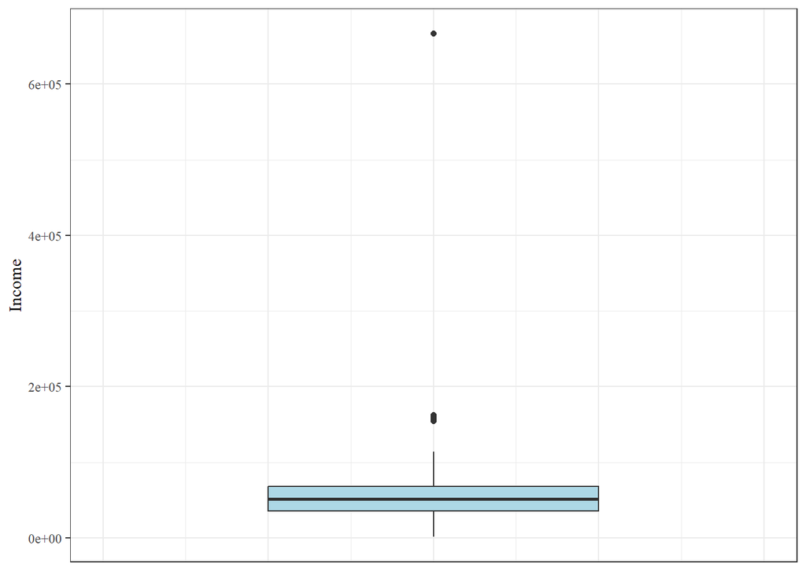

```r
p <- ggplot(df, aes(y= Income )) + geom_boxplot(fill = "lightblue", width = 0.1) +
  xlim(-0.10,0.10) +
  theme_bw() +
  theme(text = element_text(family = "serif"),
        axis.ticks.x = element_blank(),
        axis.text.x = element_blank(),
        plot.title = element_text(size = 18))


p
```

```r
ggsave("Report/images/boxplot_income.png",  width = 7, height = 6)
```

- Year of Birth

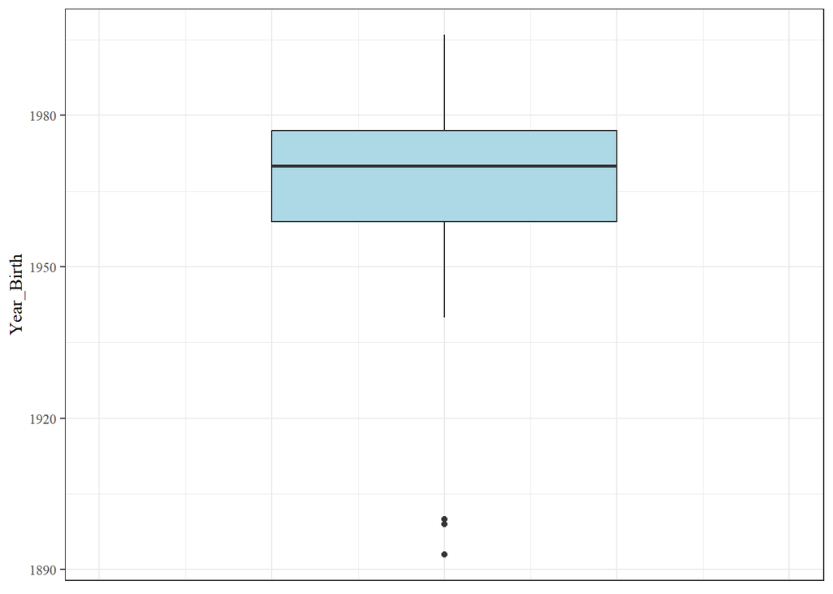

```r
p <- ggplot(df, aes(y= Year_Birth )) + geom_boxplot(fill = "lightblue", width = 0.1) +
  xlim(-0.10,0.10) +
  theme_bw() +
  theme(text = element_text(family = "serif"),
        axis.ticks.x = element_blank(),
        axis.text.x = element_blank(),
        plot.title = element_text(size = 18))


p
```

```r
ggsave("Report/images/boxplot_year.png", width = 7, height = 6)
```

Remove outliers for Year_Birth

```r
df <- df[-which(df$Year_Birth <= 1900),]
# Remove all of them
```

I decide to remove the observation with the max income

```r
df <- df[-which(df$Income == max(df$Income)),]
```

## **2.3) Encoding Variables**

The variables that need enconding are:

- Education (Basic, Graduation, 2n Cycle, Master, PhD)

Master and 2n cycle are basically the same thing so we can create one column as the sum

```r
df <- df %>%
  mutate(Education = ifelse(Education == "2n Cycle", "Master", Education))
```

```r
df$Ed_Basic <- ifelse(df$Education =="Basic", 1, 0)
df$Ed_Master <- ifelse(df$Education =="Master", 1, 0)
df$Ed_PhD <- ifelse(df$Education =="PhD", 1, 0)
df <- df %>% dplyr::select(-Education)
```

- Marital Status (Single, Together, Married, Divorced, Widow, Absurd, YOLO, Alone)

Value Absurd, Alone and YOLO do not really make sense, i will put them in the category Single.

```r
df <- df %>%
  mutate(Marital_Status = ifelse(Marital_Status %in% c("Absurd", "Alone", "YOLO"), "Single", Marital_Status))
```

Now base value will be Single

```r
df$MS_Married <- ifelse(df$Marital_Status =="Married", 1, 0)
df$MS_Together <- ifelse(df$Marital_Status =="Together", 1, 0)
df$MS_Divorced <- ifelse(df$Marital_Status =="Divorced", 1, 0)
df$MS_Widow <- ifelse(df$Marital_Status =="Widow", 1, 0)
df <- df %>% dplyr::select(-Marital_Status)
```

## **2.4) Variable Transformation**

Replace the Date a Customer has enrolled with the companies, with the number of days, he has been enrolled:

```r
max_Date <- max(df$Dt_Customer)

df <- df %>%
  mutate(enrollment_days = as.numeric(difftime(max_Date, df$Dt_Customer, units = "days")))

df <- df %>% dplyr::select(-Dt_Customer)
numerical_col = numerical_col[numerical_col != 'Dt_Customer']
numerical_col = c(numerical_col, 'enrollment_days')
```

Change Year_Birth to Age

```r
df <- df%>%
  mutate(Age = 2014 - Year_Birth)

df <- df %>% dplyr::select(-Year_Birth)
```

```r
# I keep track of the names of numerical variables in order to make it easy later to write code

numerical_col = numerical_col[ !numerical_col == 'Year_Birth']
numerical_col = c(numerical_col, "Age")
```

Aggregate the response for previous campaigns:

```r
df <- df %>%
  mutate(CmpAccepted = rowSums(dplyr::select(df, contains("Accepted") )))
Previous_campaing <- df%>% dplyr::select(starts_with("Accepted"))
df <- df %>%
  dplyr::select(-starts_with("Accepted"))
```

Rearrange the order of columns

```r
df <- df %>% relocate(contains("Accepted"), .after=last_col())
df <- df %>% relocate(Response, .after=last_col())
df <- df %>% relocate(Age) # default: move to first place
df <- df %>% relocate(starts_with("Ed"), .after=Teenhome)
df <- df %>% relocate(starts_with("MS"), .after=Ed_PhD)
df <- df %>% relocate(enrollment_days, .after = MS_Widow)
```

# **3) EXPLORATORY DATA ANALYSIS**

## **3.1) Response distribution**

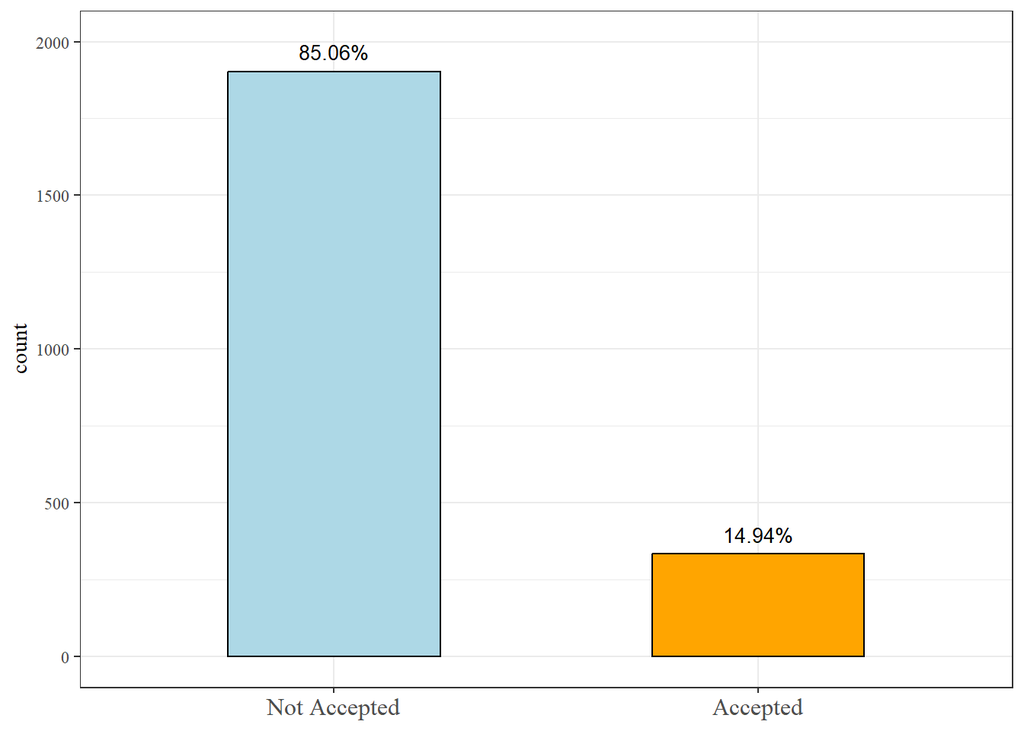

```r
p <- ggplot(df, aes(x = as.factor(Response))) +

  geom_bar(width = 0.5, aes(fill = as.factor(Response)), col = "black") +

  theme_bw() +

  scale_fill_manual(values = c("lightblue", "orange")) +

  scale_x_discrete(labels=c("0" = "Not Accepted", "1" = "Accepted")) +

  theme(text = element_text(family = "serif"),
        legend.position = "none",
        axis.text.x = element_text(size=12),
        axis.title.x = element_blank()) +


  geom_text(aes(y = ..count..,
            label = paste0(round(prop.table(..count..), 4) * 100, '%')),
            stat = 'count',
            position = position_dodge(0.3),
            size = 3.5,
            vjust = - 0.75) +

  ylim(c(0,2000))

p
```

```r
ggsave("Report/images/acceptance_rate.png", width = 7, height = 6)
```

Graph for Age groups:

```r
Age <- cut(df$Age, c(18,30,40,50,60,80), include.lowest = TRUE)
summary(Age)
```

```
## [18,30] (30,40] (40,50] (50,60] (60,80]
##     259     587     649     475     266
```

```r
df$Age_range = Age
```

```r
# Create a temporary df to store the Age range and the associated positive response percentage
# This make it easier to retrieve these values when plotting
summary_df <- df %>%
  group_by(Age_range) %>%
  summarize(
    n = n(),
    yes = sum(Response == 1),
    percentage = mean(Response)*100
  )
```

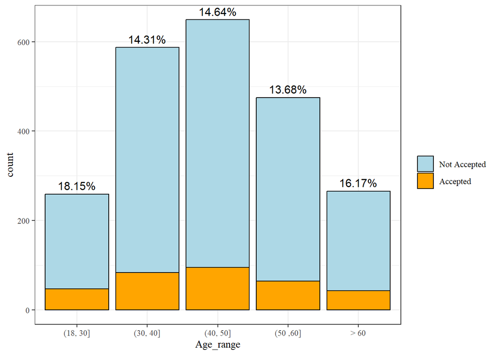

```r
p <- ggplot(df, aes(x = Age_range)) + geom_bar(aes(fill = as.factor(Response)), col = "black")+

  geom_text(aes(y = ..count..), label = paste0(round(summary_df$percentage, 2), '%'),
              stat = 'count',
              position = position_dodge(0.3),
              size = 4,
              vjust = -0.5) +

  theme_bw() +

  theme(text = element_text(family = "serif")) +

  scale_fill_manual(name = "",
                    labels = c("Not Accepted", "Accepted"),
                    values = c("lightblue", "orange")) +

  scale_x_discrete(labels = c("(18, 30]", "(30, 40]", "(40, 50]",
                              "(50 ,60]", "> 60"))
p
```

```r
ggsave("Report/images/distribution_age.png", width = 8, height = 6)
```

```r
df <- df %>% dplyr::select(-Age_range)
```

Graph for Income:

```r
Income_range <- cut(df$Income, c(0,20000,40000,60000,80000, Inf), dig.lab = 6)
df$Income_range = (Income_range)
```

```r
summary_df <- df %>%
  group_by(Income_range) %>%
  summarize(
    n = n(),
    yes = sum(Response == 1),
    percentage = mean(Response)*100
  )
```

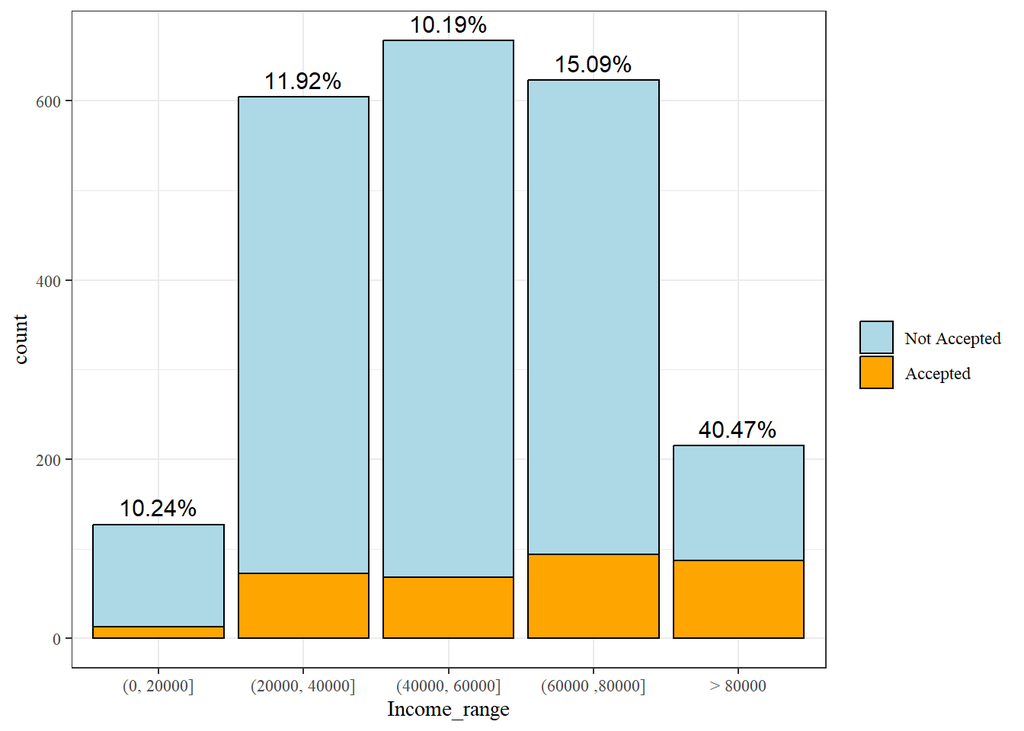

```r
p <- ggplot(df, aes(x = Income_range)) + geom_bar(aes(fill = as.factor(Response)), col = "black")+

  geom_text(aes(y = ..count..), label = paste0(round(summary_df$percentage, 2), '%'),
              stat = 'count',
              position = position_dodge(0.3),
              size = 4,
              vjust = -0.5) +

  theme_bw() +

  theme(text = element_text(family = "serif")) +

  scale_fill_manual(name = "",
                    labels = c("Not Accepted", "Accepted"),
                    values = c("lightblue", "orange")) +
  scale_x_discrete(labels = c("(0, 20000]", "(20000, 40000]", "(40000, 60000]",
                              "(60000 ,80000]", "> 80000"))

p
```

```r
ggsave("Report/images/distribution_income.png", width = 8, height = 6)
```

```r
df <- df %>% dplyr::select(-Income_range)
```

```r
summary_df <- df %>%
  group_by(CmpAccepted) %>%
  summarize(
    count = n(),
    percentage = n()/length(df)
  )

summary_df
```

```
## # A tibble: 5 × 3
##   CmpAccepted count percentage
##         <dbl> <int>      <dbl>
## 1           0  1774     65.7
## 2           1   324     12
## 3           2    83      3.07
## 4           3    44      1.63
## 5           4    11      0.407
```

## **3.2) Correlation**

```r
correlation_matrix <- cor(df)
```

```
##                    Var1                Var2       Freq
## 583     MntMeatProducts NumCatalogPurchases  0.7234735
## 569              Income NumCatalogPurchases  0.6937813
## 353              Income            MntWines  0.6860804
## 407              Income     MntMeatProducts  0.6841762
## 623              Income   NumWebVisitsMonth -0.6463820
## 608            MntWines   NumStorePurchases  0.6423128
## 581            MntWines NumCatalogPurchases  0.6347155
## 596              Income   NumStorePurchases  0.6280753
## 447           MntFruits     MntFishProducts  0.5944152
## 476     MntFishProducts    MntSweetProducts  0.5794898
## 448     MntMeatProducts     MntFishProducts  0.5678127
## 474           MntFruits    MntSweetProducts  0.5670295
## 419            MntWines     MntMeatProducts  0.5618860
## 554            MntWines     NumWebPurchases  0.5421356
## 420           MntFruits     MntMeatProducts  0.5420302
## 637     MntMeatProducts   NumWebVisitsMonth -0.5391826
## 584     MntFishProducts NumCatalogPurchases  0.5339686
## 475     MntMeatProducts    MntSweetProducts  0.5233288
## 643 NumCatalogPurchases   NumWebVisitsMonth -0.5203756
## 616 NumCatalogPurchases   NumStorePurchases  0.5187885
## 434              Income     MntFishProducts  0.5184616
## 461              Income    MntSweetProducts  0.5181264
## 689            MntWines         CmpAccepted  0.5118799
## 56               Income             Kidhome -0.5104409
## 380              Income           MntFruits  0.5049111
## 570             Kidhome NumCatalogPurchases -0.5023313
## 615     NumWebPurchases   NumStorePurchases  0.5022269
## 597             Kidhome   NumStorePurchases -0.5001922
```

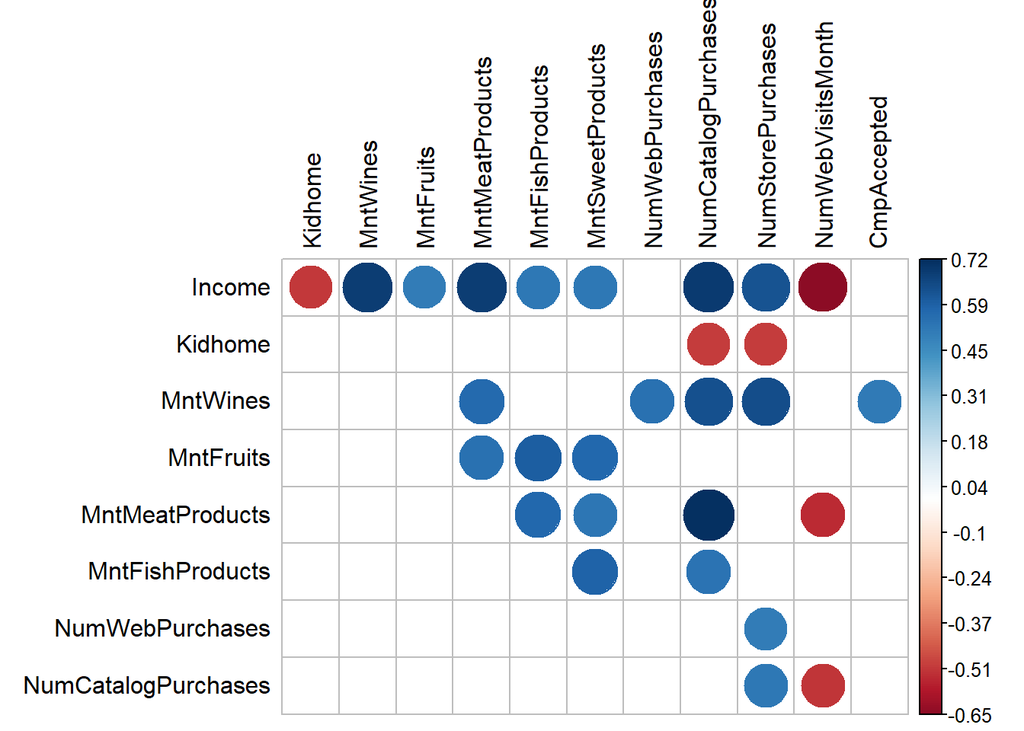

```r
# Nice function that i found online that makes the corrplot easier to read

corr_simple <- function(data=df,sig=0.5){
  #convert data to numeric in order to run correlations
  #convert to factor first to keep the integrity of the data - each value will become a number rather than turn into NA
  df_cor <- data %>% mutate_if(is.character, as.factor)
  df_cor <- df_cor %>% mutate_if(is.factor, as.numeric)
  #run a correlation and drop the insignificant ones
  corr <- cor(df_cor)
  #prepare to drop duplicates and correlations of 1
  corr[lower.tri(corr,diag=TRUE)] <- NA
  #drop perfect correlations
  corr[corr == 1] <- NA
  #turn into a 3-column table
  corr <- as.data.frame(as.table(corr))
  #remove the NA values from above
  corr <- na.omit(corr)
  #select significant values
  corr <- subset(corr, abs(Freq) > sig)
  #sort by highest correlation
  corr <- corr[order(-abs(corr$Freq)),]
  #print table
  print(corr)
  #turn corr back into matrix in order to plot with corrplot
  mtx_corr <- reshape2::acast(corr, Var1~Var2, value.var="Freq")

  #plot correlations visually
  corrplot(mtx_corr, is.corr=FALSE, tl.col="black", na.label=" ")
}

corr_simple()
```

Check the variance inflation factor

```r
vif_model <- glm(Response ~., data = df, family = "binomial")
vif_values <- vif(vif_model)
print(vif_values)
```

```
##                 Age              Income             Kidhome            Teenhome
##            1.320677            5.441879            2.047068            1.826551
##            Ed_Basic           Ed_Master              Ed_PhD          MS_Married
##            1.061497            1.200418            1.365833            1.503914
##         MS_Together         MS_Divorced            MS_Widow     enrollment_days
##            1.377644            1.302981            1.183939            1.392091
##             Recency            MntWines           MntFruits     MntMeatProducts
##            1.139512            3.508245            1.971201            3.041885
##     MntFishProducts    MntSweetProducts        MntGoldProds   NumDealsPurchases
##            2.018118            1.798929            1.441604            1.867200
##     NumWebPurchases NumCatalogPurchases   NumStorePurchases   NumWebVisitsMonth
##            1.632200            2.832705            2.142698            3.055628
##            Complain         CmpAccepted
##            1.013671            1.803909
```

In order to avoid problem of multicollinearity and predictors with reduntant information, I transform the varaibles containing the amount of money spent in each category of product and sale channel into their percentage with respect to the total amount spent.

```r
money = df %>% dplyr::select(starts_with("Mnt")) %>% dplyr::select(-"MntGoldProds")
df = df %>% mutate(
  Total = rowSums(money),
  MntWines = MntWines/Total*100,
  MntFruits = MntFruits/Total*100,
  MntFishProducts = MntFishProducts/Total*100,
  MntMeatProducts = MntMeatProducts/Total*100,
  MntSweetProducts = MntSweetProducts/Total*100,
  MntGoldProds = MntGoldProds/Total*100
) %>% dplyr::select(-Total, -MntMeatProducts)
```

```r
purchases = df %>% dplyr::select(starts_with("Num")) %>% dplyr::select(-c("NumDealsPurchases", "NumWebVisitsMonth"))

df = df %>% mutate(
  Total = rowSums(purchases),
  NumWebPurchases = ifelse(Total !=0, NumWebPurchases/Total *100, 0),
  NumCatalogPurchases = ifelse(Total != 0, NumCatalogPurchases/Total*100, 0),
  NumStorePurchases = ifelse(Total != 0, NumStorePurchases/Total*100,0)
) %>% dplyr::select(-Total, -NumStorePurchases)
```

```r
vif_model <- glm(Response ~., data = df, family = "binomial")
vif_values <- vif(vif_model)
print(vif_values)
```

```
##                 Age              Income             Kidhome            Teenhome
##            1.305677            3.958772            1.925891            1.893585
##            Ed_Basic           Ed_Master              Ed_PhD          MS_Married
##            1.207340            1.191190            1.362537            1.510933
##         MS_Together         MS_Divorced            MS_Widow     enrollment_days
##            1.387084            1.300353            1.179423            1.380742
##             Recency            MntWines           MntFruits     MntFishProducts
##            1.163011            3.791607            1.829519            1.722999
##    MntSweetProducts        MntGoldProds   NumDealsPurchases     NumWebPurchases
##            1.588314            1.404843            1.800484            1.904436
## NumCatalogPurchases   NumWebVisitsMonth            Complain         CmpAccepted
##            2.133059            3.853770            1.018524            1.698575
```

# **4) UNSUPERVISED LEARNING**

```r
df_uns <- df %>% dplyr::select(-Response)
```

```r
numerical_col = c(numerical_col, "Kidhome", "Teenhome", "CmpAccepted")
numerical_col = numerical_col[! numerical_col %in% c("MntMeatProducts", "NumStorePurchases")]
categorical_col <- colnames(df_uns %>% dplyr::select(-all_of(numerical_col)))
```

# **4.1) FULL SET OF VARIABLES**

Try to cluster the data with hierarchical clustering

```r
# Select the columns that you want to include in the distance calculation
temp_df <- as.data.frame(lapply(df_uns[, numerical_col], scale))

# the transofrmation to factor of categorical columns is needed for the daisy
# function to recognize them as such
categorical_columns <- lapply(df_uns[, categorical_col], as.factor)
numerical_columns <- temp_df[numerical_col]

# Compute the Gower distance
gower_distances <- daisy(cbind(categorical_columns, numerical_columns), metric = "gower")
```

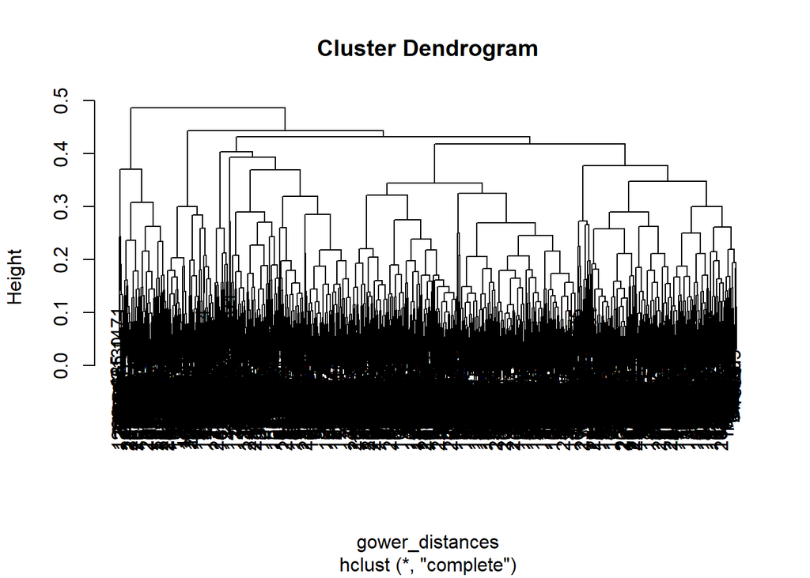

```r
hc <- hclust(gower_distances, method='complete')
plot(hc)
```

```r
clusters <- cutree(hc, 3)
table(clusters, df$Response)
```

```
##
## clusters    0    1
##        1 1631  258
##        2  151   21
##        3  120   55
```

```r
df$cluster <- clusters
df %>% group_by(cluster) %>% summarize(across(everything(), mean))
```

```
## # A tibble: 3 × 26
##   cluster   Age Income Kidhome Teenhome Ed_Basic Ed_Master Ed_PhD MS_Married
##     <int> <dbl>  <dbl>   <dbl>    <dbl>    <dbl>     <dbl>  <dbl>      <dbl>
## 1       1  44.3 51305.   0.442    0.483   0.0286     0.302 0.0731     0.427
## 2       2  49.0 46644.   0.808    0.872   0          0     1          0.233
## 3       3  49.5 64163.   0.109    0.406   0          0     1          0.0971
## # ℹ 17 more variables: MS_Together <dbl>, MS_Divorced <dbl>, MS_Widow <dbl>,
## #   enrollment_days <dbl>, Recency <dbl>, MntWines <dbl>, MntFruits <dbl>,
## #   MntFishProducts <dbl>, MntSweetProducts <dbl>, MntGoldProds <dbl>,
## #   NumDealsPurchases <dbl>, NumWebPurchases <dbl>, NumCatalogPurchases <dbl>,
## #   NumWebVisitsMonth <dbl>, Complain <dbl>, CmpAccepted <dbl>, Response <dbl>
```

## **4.2) HIERARCHICAL CLUSTERING WITH TRANSFORMED VARIABLES**

```r
# df_uns_compact represents the dataframe with less binary variables

df_uns_compact = df_uns
df_uns_compact = df_uns_compact %>%
  mutate(
  MS_Together = ifelse(MS_Together == 1 | MS_Married == 1, 1, 0),
  Higher_ed = ifelse(Ed_Master == 1 | Ed_PhD == 1, 1, 0)) %>%

  dplyr::select(-c("Ed_Basic", "Ed_Master", "Ed_PhD", "MS_Married", "MS_Divorced", "MS_Widow"))

# df_compact is the df_uns_compact plus the target variable
df_compact = df_uns_compact
df_compact$Response = df$Response
```

```r
# Since we have change the categorical variables, we need a new vector to store
# the names of this subset of categorical variables

cat_red = categorical_col[! categorical_col %in% c("Ed_Basic", "Ed_Master", "Ed_PhD", "MS_Married", "MS_Divorced", "MS_Widow")]
temp_df <- as.data.frame(lapply(df_uns_compact[, numerical_col], scale))
categorical_columns <- lapply(df_uns_compact[, cat_red], as.factor)
numerical_columns <- temp_df[numerical_col]

# Compute the Gower distance
gower_distances <- daisy(cbind(categorical_columns, numerical_columns), metric = "gower")
```

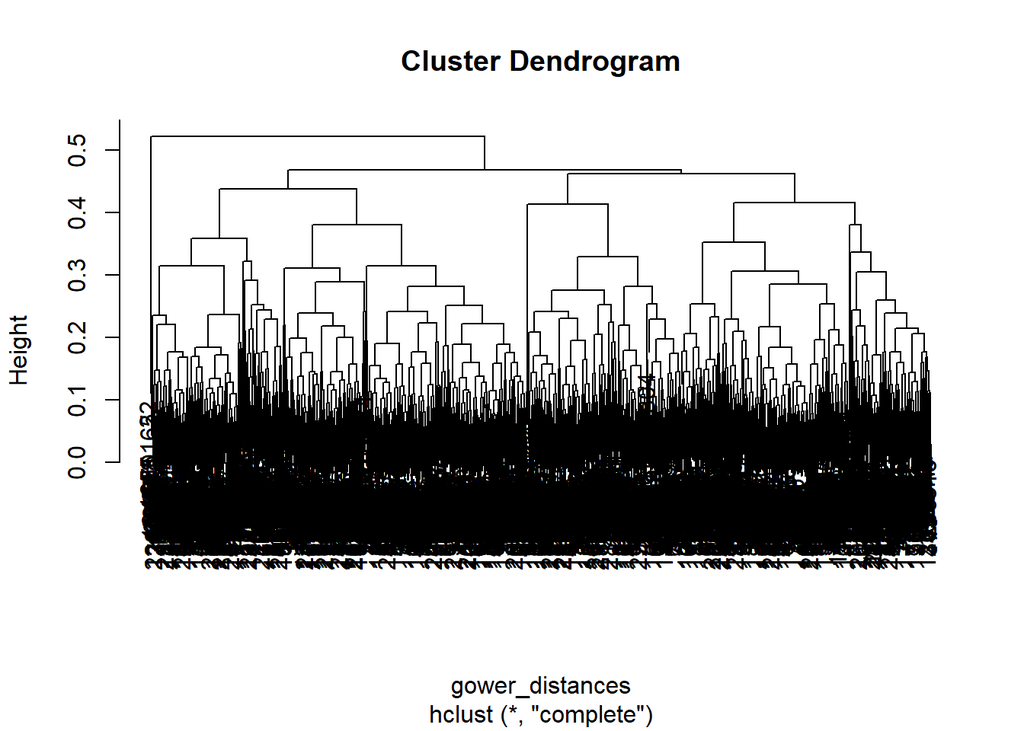

```r
hc <- hclust(gower_distances, method='complete')
plot(hc)
```

```r
clusters <- cutree(hc, 3)
table(clusters, df_compact$Response)
```

```
##
## clusters   0   1
##        1 900 259
##        2 998  75
##        3   4   0
```

```r
df_compact$cluster <- clusters
df_compact %>% group_by(cluster) %>% summarize(across(everything(), mean))
```

```
## # A tibble: 3 × 21
##   cluster   Age  Income Kidhome Teenhome MS_Together enrollment_days Recency
##     <int> <dbl>   <dbl>   <dbl>    <dbl>       <dbl>           <dbl>   <dbl>
## 1       1  45.1  57533.   0.341    0.340       0.318            355.    47.1
## 2       2  45.2  45674.   0.556    0.688       0.997            352.    51.3
## 3       3  36.2 119410.   0.25     0.25        1                445.    43.5
## # ℹ 13 more variables: MntWines <dbl>, MntFruits <dbl>, MntFishProducts <dbl>,
## #   MntSweetProducts <dbl>, MntGoldProds <dbl>, NumDealsPurchases <dbl>,
## #   NumWebPurchases <dbl>, NumCatalogPurchases <dbl>, NumWebVisitsMonth <dbl>,
## #   Complain <dbl>, CmpAccepted <dbl>, Higher_ed <dbl>, Response <dbl>
```

We note that a cluster is composed of only 4 observations, which have been classified as outliers. We try now to use again hierachical clustering without those observations

```r
index_to_remove = which(df_compact$cluster ==3)
df_compact = df_compact[- which(colnames(df_compact) == "cluster")]

#df_compact_removed and df_uns_compact_removed are the new version of the compact
# dataframes without the outliers

df_compact_removed = df_compact[-index_to_remove,]

df_uns_compact_removed = df_compact_removed[-which(colnames(df_compact_removed)== "Response")]
```

```r
temp_df <- as.data.frame(lapply(df_uns_compact_removed[, numerical_col], scale))
categorical_columns <- lapply(df_uns_compact_removed[, cat_red], as.factor)
numerical_columns <- temp_df[numerical_col]

# Compute the Gower distance
gower_distances <- daisy(cbind(categorical_columns, numerical_columns), metric = "gower")
```

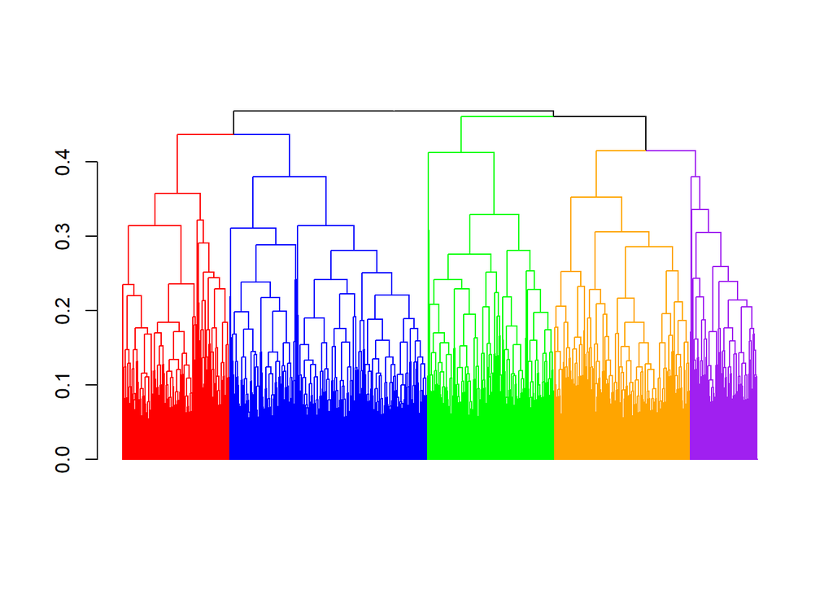

```r
hc <- hclust(gower_distances, method='complete')
dend <- as.dendrogram(hc)
dend %>% set("branches_k_color",
             value = c("red", "blue", "green", "orange", "purple"), k = 5) %>%
  set("labels_col", "white") %>%
   plot(cex = 0.001)
```

```r
clusters <- cutree(hc, 5)
table(clusters, df_compact_removed$Response)
```

```
##
## clusters   0   1
##        1 193  42
##        2 381  64
##        3 326 153
##        4 349  27
##        5 649  48
```

```r
df_compact_removed$cluster = as.factor(clusters)
df_compact_removed %>% group_by(cluster) %>% summarize(across(everything(), mean))
```

```
## # A tibble: 5 × 21
##   cluster   Age Income Kidhome Teenhome MS_Together enrollment_days Recency
##   <fct>   <dbl>  <dbl>   <dbl>    <dbl>       <dbl>           <dbl>   <dbl>
## 1 1        38.1 32261.   0.791   0.0468     0                  352.    47.2
## 2 2        50.0 56328.   0.337   0.843      0.00449            342.    50.9
## 3 3        43.9 71051.   0.123   0.0167     0.764              369.    43.5
## 4 4        36.8 31804.   0.838   0.0452     0.992              337.    53.0
## 5 5        49.7 53156.   0.405   1.03       1                  360.    50.4
## # ℹ 13 more variables: MntWines <dbl>, MntFruits <dbl>, MntFishProducts <dbl>,
## #   MntSweetProducts <dbl>, MntGoldProds <dbl>, NumDealsPurchases <dbl>,
## #   NumWebPurchases <dbl>, NumCatalogPurchases <dbl>, NumWebVisitsMonth <dbl>,
## #   Complain <dbl>, CmpAccepted <dbl>, Higher_ed <dbl>, Response <dbl>
```

## **4.3) INSPECT THE RESULTS**

In order to visualize also the differences among groups for the category of product and channel of sales that have been previously removed we add them back to the dataframe with reverse engineering.

```r
df_compact_removed$MntMeatProducts = 100 - rowSums(df_compact_removed[c("MntWines", "MntFruits", "MntFishProducts", "MntSweetProducts")])
df_compact_removed$NumStorePurchases = 100 - rowSums(df_compact_removed[c("NumWebPurchases", "NumCatalogPurchases")])
```

We now create two functions to plot variables for each cluster. The *bars* function plots barplots of categorical and discrete variables. The bars represents the percentage of each cluster in one category. The *densities* function plots density plots for continuous variables.

```r
bars <- function(x, var) { #x = cluster, var = variable we want to plot

  # the levels represent the name of the clusters
  levels = c("1", "2", "3", "4", "5")
  res = x

  # colors and associated name are needed so that in the plot, only the cluster of interest
  # will have a different color
  colors = c(ifelse(levels == res, "gold1", "grey"))
  names(colors) = levels

  # we want to compute the percentage of observation for each cluster that falls into each level
  # the function table creates a table with a column cluster, and then one column for each level of the predictors
  # the cells are filled with the number of observations that falls into that the level for each cluster
  # then the function prob.table computes the frequency of each level by row
  percentage_df <- as.data.frame(prop.table(

                    table(df_compact_removed[c("cluster", var)]),

                    margin = 1))

  #create a new column called col in order to avoid problem of name references in the plot function
  percentage_df$col = percentage_df[[var]]

  # plot the barplot where on the x we have the levels and on the y the relative frequency
  ggplot(percentage_df, aes(x = col, y = Freq, fill = cluster)) +

    geom_bar(stat = "identity", position = "dodge", col = "black") +

    scale_fill_manual(values = colors) +

    theme_bw()+

    theme(text = element_text(family = "serif", size = 14),
        axis.text.x  = element_text(size=22),
        axis.text.y  = element_text(size=22)) +

    xlab(var)

}
```

```r
densities <- function(x, var) {

  levels = c("1", "2", "3", "4", "5")
  res = x

  colors = c(ifelse(levels == res, "gold1", "grey"))
  names(colors) = levels

  # here we don't have to extrace the frequencies, but we just need the values
  temp_df = data.frame(col = df_compact_removed[[var]],
                            "cluster" = df_compact_removed$cluster)

  # we reorder the cluster so that in the plot the cluster of interest will be plot
  # in front of the ohters
  temp_df$cluster = reorder(temp_df$cluster, temp_df$cluster == x)


  ggplot(temp_df, aes(fill = cluster, x = col)) +

    geom_density(position="identity", alpha = 0.5, col = "black") +

    scale_fill_manual(values = colors) +

    theme_bw()+

    theme(text = element_text(family = "serif", size = 14),
          axis.text.x  = element_text(size=22),
          axis.text.y  = element_text(size=22)) +

    xlab(var)
}
```

Now for each cluster we just plot all the variables that we need for the report. Only the variables that showed an interesting pattern have been plotted.

```r
bars("1", "Kidhome")
ggsave("Report/images/group1_kid.png", width = 7, height = 5)
bars("1", "Teenhome")
ggsave("Report/images/group1_teen.png", width = 7, height = 5)
bars("1", "MS_Together")
ggsave("Report/images/group1_married.png", width = 7, height = 5)
densities("1", "Income")
ggsave("Report/images/group1_income.png", width = 7, height = 5)
densities("1", "MntFruits")
ggsave("Report/images/group1_fruits.png", width = 7, height = 5)
densities("1", "MntWines")
ggsave("Report/images/group1_wines.png", width = 7, height = 5)
densities("1", "Age")
ggsave("Report/images/group1_age.png", width = 7, height = 5)
```

```r
bars("2", "Kidhome")
ggsave("Report/images/group2_kid.png", width = 7, height = 5)
bars("2", "Teenhome")
ggsave("Report/images/group2_teen.png", width = 7, height = 5)
bars("2", "MS_Together")
ggsave("Report/images/group2_married.png", width = 7, height = 5)
densities("2", "Income")
ggsave("Report/images/group2_income.png", width = 7, height = 5)
densities("2", "Age")
ggsave("Report/images/group2_age.png", width = 7, height = 5)
densities("2", "MntWines")
ggsave("Report/images/group2_wines.png", width = 7, height = 5)
densities("2", "MntMeatProducts")
ggsave("Report/images/group2_meat.png", width = 7, height = 5)
```

```r
bars("3", "Kidhome")
ggsave("Report/images/group3_kid.png", width = 7, height = 5)
bars("3", "Teenhome")
ggsave("Report/images/group3_teen.png", width = 7, height = 5)
bars("3", "MS_Together")
ggsave("Report/images/group3_married.png", width = 7, height = 5)
bars("3", "Response")
ggsave("Report/images/group3_response.png", width = 7, height = 5)
densities("3", "Income")
ggsave("Report/images/group3_income.png", width = 7, height = 5)
densities("3", "MntGoldProds") + xlim(0,50)
ggsave("Report/images/group3_gold.png", width = 7, height = 5)
bars("4", "Kidhome")
ggsave("Report/images/group4_kid.png", width = 7, height = 5)
bars("4", "Teenhome")
ggsave("Report/images/group4_teen.png", width = 7, height = 5)
bars("4", "MS_Together")
ggsave("Report/images/group4_married.png", width = 7, height = 5)
bars("4", "Response")
ggsave("Report/images/group4_response.png", width = 7, height = 5)
densities("4", "Income")
ggsave("Report/images/group4_income.png", width = 7, height = 5)
densities("4", "MntGoldProds") + xlim(0,50)
ggsave("Report/images/group4_gold.png", width = 7, height = 5)
densities("4", "Age")
ggsave("Report/images/group4_age.png", width = 7, height = 5)
densities("4", "MntSweetProducts")
ggsave("Report/images/group4_sweet.png", width = 7, height = 5)
densities("4", "MntFruits")
ggsave("Report/images/group4_fruits.png", width = 7, height = 5)
```

```r
bars("5", "Kidhome")
ggsave("Report/images/group5_kid.png", width = 7, height = 5)
bars("5", "Teenhome")
ggsave("Report/images/group5_teen.png", width = 7, height = 5)
bars("5", "MS_Together")
ggsave("Report/images/group5_married.png", width = 7, height = 5)
bars("5", "Response")
ggsave("Report/images/group5_response.png", width = 7, height = 5)
densities("5", "Age")
ggsave("Report/images/group5_age.png", width = 7, height = 5)
densities("5", "MntMeatProducts")
ggsave("Report/images/group5_meat.png", width = 7, height = 5)
densities("5", "MntWines")
ggsave("Report/images/group5_wines.png", width = 7, height = 5)
```

# **5) SUPERVISED LEARNING**

```r
df <- df %>% dplyr::select(-cluster)
```

```r
split_train_test <- createDataPartition(df$Response, p=0.8, list=FALSE)
dtrain <- df[split_train_test,]
dtest <-  df[-split_train_test,]
```

For what I want to do later, I found it easier to create a *Model* class, which use the predicted probabilities and the provided treshold to make predictions and store the results in terms of precison and recall

```r
setClass("Model", representation(

  predicted_prob = "numeric",       # predicted probabilities computed by the algorithm for each observation

  treshold = "numeric",             # threshold according to which the algorithm classify the observation

  predicted_class = "numeric",

  pr_data = "tbl_df",               # attribute in which is store the precision recall curve

  precision = "numeric",

  recall = "numeric",

  auc_pr = "numeric",               # Area under the curve of the precision recall curve

  response = "numeric",             # Target variable

  conf_matrix = "table",            # confusion matrix

  event_level = "character"         # a string needed to specify whether the positive class is observed as first or second in the dataset
))

# method to initialize the confusion matrix

initialize_conf_matrix <- function(.Object) {

  #add the attribute to the Object
  .Object@conf_matrix <-  as.table(confusionMatrix(as.factor(.Object@predicted_class),
                              as.factor(.Object@response)))

  #return the object
  .Object

}


# method to initialize the other attributes not provided by the user

initialize_values <- function(.Object, event_level) {

  data <- data.frame(truth = as.factor(.Object@response),
                               pred_prob = .Object@predicted_prob,
                               pred_class = as.factor(.Object@predicted_class))

  auc_pr <- data %>%
              pr_auc(truth, pred_prob, event_level = event_level)

  recall <- data %>%
              recall(truth, pred_class, event_level = event_level)

  precision <- data %>%
              precision(truth, pred_class, event_level = event_level)


  .Object@auc_pr <- auc_pr$.estimate
  .Object@recall <- recall$.estimate
  .Object@precision <- precision$.estimate

  return(.Object)

}

#initialize the attributes passed by the user

setMethod("initialize", "Model",

          function(.Object, predicted_prob,
                   predicted_class, treshold,
                   Response = dtest$Response,
                   event_level = "first") {

                        .Object@predicted_prob = predicted_prob

                        .Object@treshold = treshold

                        .Object@predicted_class = ifelse(.Object@predicted_prob > .Object@treshold, 1,0)

                        .Object@response = Response

                        .Object@event_level = event_level

                        .Object <- initialize_conf_matrix(.Object)

                        .Object <- initialize_values(.Object, .Object@event_level)

                        return(.Object)

                }
)

#create a method to prince the precision recall curve

setGeneric("print_pr", function(.Object) standardGeneric("print_pr"))
```

```
## [1] "print_pr"
```

```r
setMethod("print_pr", signature(.Object = "Model"),
          function(.Object) {

            data <- data.frame(truth = as.factor(.Object@response),
                               pred_prob = .Object@predicted_prob,
                               pred_class = as.factor(.Object@predicted_class))

            pr_data <- data %>%
              pr_curve(truth, pred_prob, event_level = .Object@event_level)

            pr_plot <- pr_data %>% autoplot()

            return(pr_plot)

          })
```

## **5.1) Logistic Model**

```r
#fit the logistic model
logistic_model <-glm(Response ~., data=dtrain , family="binomial" )
summary(logistic_model)
```

```
##
## Call:
## glm(formula = Response ~ ., family = "binomial", data = dtrain)
##
## Coefficients:
##                       Estimate Std. Error z value Pr(>|z|)
## (Intercept)         -3.744e+00  9.288e-01  -4.031 5.54e-05 ***
## Age                  1.514e-02  8.437e-03   1.794  0.07274 .
## Income               1.424e-06  8.048e-06   0.177  0.85955
## Kidhome              3.391e-01  2.404e-01   1.411  0.15829
## Teenhome            -6.936e-01  2.414e-01  -2.873  0.00407 **
## Ed_Basic            -1.163e+00  9.265e-01  -1.255  0.20947
## Ed_Master            4.337e-01  2.268e-01   1.912  0.05588 .
## Ed_PhD               1.317e+00  2.370e-01   5.557 2.74e-08 ***
## MS_Married          -1.493e+00  2.403e-01  -6.212 5.23e-10 ***
## MS_Together         -1.446e+00  2.669e-01  -5.418 6.04e-08 ***
## MS_Divorced          2.590e-02  3.000e-01   0.086  0.93121
## MS_Widow            -2.462e-03  4.166e-01  -0.006  0.99528
## enrollment_days      4.809e-03  5.505e-04   8.736  < 2e-16 ***
## Recency             -3.310e-02  3.471e-03  -9.537  < 2e-16 ***
## MntWines            -4.386e-02  7.497e-03  -5.850 4.91e-09 ***
## MntFruits           -1.547e-02  1.572e-02  -0.984  0.32516
## MntFishProducts     -5.999e-02  1.529e-02  -3.924 8.72e-05 ***
## MntSweetProducts    -2.376e-02  1.485e-02  -1.600  0.10969
## MntGoldProds         2.015e-03  2.496e-03   0.807  0.41948
## NumDealsPurchases    2.692e-02  5.616e-02   0.479  0.63169
## NumWebPurchases      4.806e-02  9.440e-03   5.091 3.56e-07 ***
## NumCatalogPurchases  5.506e-02  9.269e-03   5.940 2.85e-09 ***
## NumWebVisitsMonth    8.593e-02  6.632e-02   1.296  0.19511
## Complain            -2.070e-01  1.522e+00  -0.136  0.89182
## CmpAccepted          1.844e+00  1.480e-01  12.458  < 2e-16 ***
## ---
## Signif. codes:  0 '***' 0.001 '**' 0.01 '*' 0.05 '.' 0.1 ' ' 1
##
## (Dispersion parameter for binomial family taken to be 1)
##
##     Null deviance: 1514.71  on 1788  degrees of freedom
## Residual deviance:  835.17  on 1764  degrees of freedom
## AIC: 885.17
##
## Number of Fisher Scoring iterations: 7
```

```r
logistic_prediction <- data.frame(predict(logistic_model, dtest, type= "response"))
logistic_prediction <- logistic_prediction[[1]]
```

With the lines of code below (which recur later for each model) the predicted probabilities are used to predict the class of each observations using different thresholds. The results are then stored in a dataframe

```r
logistic_results = data.frame(treshold = numeric(0),
                              precision = numeric(0),
                              recall = numeric(0))

for (value in seq(0.01, 0.99, by = 0.01)) {

  logistic <- new("Model", predicted_prob = logistic_prediction,
                treshold = value, event_level = "second")

  row <- data.frame(treshold = value,
                    precision = logistic@precision,
                    recall = logistic@recall)

  logistic_results <- rbind(logistic_results, row)

}
```

## **5.2) STEPWISE SELECTION LOGISTIC MODEL**

```r
fullModel = glm(Response ~., data = df, family = "binomial")
nullModel = glm(Response ~1, data = df, family = "binomial")
step_logistic <- stepAIC(nullModel,
                direction = 'forward',
                scope = list(upper = fullModel,
                             lower = nullModel), trace = FALSE)
summary(step_logistic)
```

```
##
## Call:
## glm(formula = Response ~ CmpAccepted + enrollment_days + Recency +
##     NumCatalogPurchases + NumWebPurchases + Teenhome + MS_Married +
##     MS_Together + Ed_PhD + MntWines + MntFishProducts + Ed_Basic +
##     NumWebVisitsMonth + Kidhome + Age + MntSweetProducts, family = "binomial",
##     data = df)
##
## Coefficients:
##                       Estimate Std. Error z value Pr(>|z|)
## (Intercept)         -3.7406125  0.6167492  -6.065 1.32e-09 ***
## CmpAccepted          1.7702394  0.1267783  13.963  < 2e-16 ***
## enrollment_days      0.0045085  0.0004713   9.567  < 2e-16 ***
## Recency             -0.0332870  0.0030368 -10.961  < 2e-16 ***
## NumCatalogPurchases  0.0582430  0.0077110   7.553 4.24e-14 ***
## NumWebPurchases      0.0451358  0.0078404   5.757 8.57e-09 ***
## Teenhome            -0.7154846  0.1891730  -3.782 0.000155 ***
## MS_Married          -1.3626828  0.1885514  -7.227 4.93e-13 ***
## MS_Together         -1.2727793  0.2141315  -5.944 2.78e-09 ***
## Ed_PhD               1.0573284  0.1919771   5.508 3.64e-08 ***
## MntWines            -0.0391837  0.0060158  -6.513 7.34e-11 ***
## MntFishProducts     -0.0598297  0.0134182  -4.459 8.24e-06 ***
## Ed_Basic            -2.0744685  0.8561259  -2.423 0.015389 *
## NumWebVisitsMonth    0.1103093  0.0473611   2.329 0.019853 *
## Kidhome              0.4382205  0.1938596   2.261 0.023790 *
## Age                  0.0153650  0.0072205   2.128 0.033340 *
## MntSweetProducts    -0.0207521  0.0122075  -1.700 0.089141 .
## ---
## Signif. codes:  0 '***' 0.001 '**' 0.01 '*' 0.05 '.' 0.1 ' ' 1
##
## (Dispersion parameter for binomial family taken to be 1)
##
##     Null deviance: 1885.5  on 2235  degrees of freedom
## Residual deviance: 1072.4  on 2219  degrees of freedom
## AIC: 1106.4
##
## Number of Fisher Scoring iterations: 6
```

```r
step_logistic_prediction <- data.frame(predict(step_logistic, dtest, type= "response"))
step_logistic_prediction <- step_logistic_prediction[[1]]
```

```r
step_logistic_results = data.frame(treshold = numeric(0),
                              precision = numeric(0),
                              recall = numeric(0))

for (value in seq(0.01, 0.99, by = 0.01)) {

  step_logistic <- new("Model", predicted_prob = step_logistic_prediction,
                treshold = value, event_level = "second")

  row <- data.frame(treshold = value,
                    precision = step_logistic@precision,
                    recall = step_logistic@recall)

  step_logistic_results <- rbind(step_logistic_results, row)

}
```

## **5.3 LASSO FOR BINARY**

Since Lasso regression puts constraints on the size of the coefficients, which depend on the magnitude of the varaibles, before applying it, I scaled all the numerical variables

```r
dtrain_scale <- dtrain
dtrain_scale[numerical_col] = as.data.frame(lapply(dtrain[numerical_col], scale))
dtest_scale <- dtest
dtest_scale[numerical_col] = as.data.frame(lapply(dtest[numerical_col], scale))
```

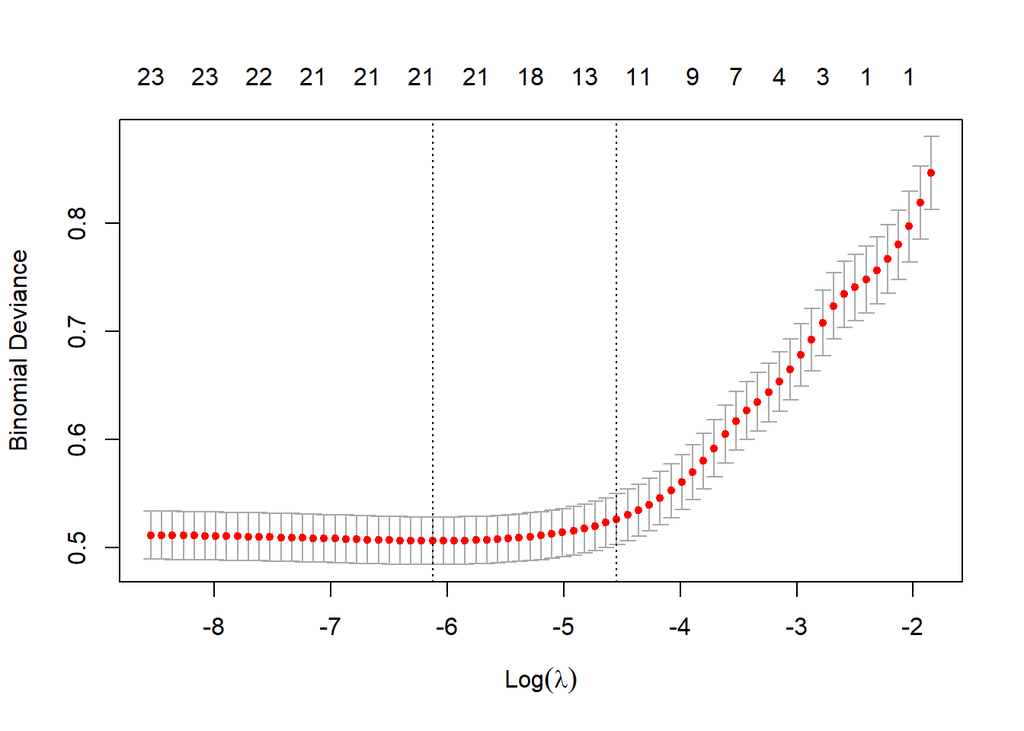

```r
#i create the variable x/y train and test because the glmnet requires different
#arguments than glm

x_train = as.matrix(dtrain_scale[,-which(names(df) =="Response")])
y_train = dtrain_scale$Response
x_test = as.matrix(dtest_scale[,-which(names(df) =="Response")])
y_test = dtest_scale$Response

#use cross valdiation to determine the best value for lambda
lasso_cv <- cv.glmnet(x_train, y_train, alpha=1, family = "binomial")
plot(lasso_cv)
```

```r
#select the highest value of lambda within one standard deviation from the minimum value
optimal_lambda <- lasso_cv$lambda.1se
```

```r
lasso_model <- glmnet(x_train, y_train, alpha = 1, family = "binomial",
                      lambda = optimal_lambda)
```

```r
lasso_pred <- predict(lasso_model, newx = x_test, s=optimal_lambda, type = "response")
lasso_prob <- lasso_pred[,1]
```

```r
lasso_results = data.frame(treshold = numeric(0),
                              precision = numeric(0),
                              recall = numeric(0))

for (value in seq(0.01, 0.90, by = 0.01)) {

  lasso <- new("Model", predicted_prob = lasso_prob,
                treshold = value, event_level = "second")

  row <- data.frame(treshold = value,
                    precision = lasso@precision,
                    recall = lasso@recall)

  lasso_results <- rbind(lasso_results, row)

}
```

## **5.4 Linear Discriminant Analysis**

```r
lda_model <- lda(Response~.,data = dtrain)
```

Show the coefficient of the first discriminant function:

```r
variable_names <- colnames(dplyr::select(df, -Response))
lda_coefficients_with_names <- data.frame(Coefficient = lda_model$scaling)
print(format(arrange(lda_coefficients_with_names, desc(abs(LD1))), scientific = FALSE))
```

```
##                                  LD1
## CmpAccepted          1.2760774475957
## MS_Together         -0.6889537220404
## Ed_PhD               0.6281087005025
## MS_Married          -0.6258450457468
## Complain             0.3491463646896
## Ed_Basic            -0.3383488647614
## Teenhome            -0.2246094504575
## Ed_Master            0.1893923883414
## Kidhome              0.1164373842343
## MS_Widow             0.0749103257095
## MS_Divorced         -0.0529912424200
## NumWebVisitsMonth    0.0322062291918
## NumCatalogPurchases  0.0220656425803
## MntFishProducts     -0.0216958653177
## MntWines            -0.0198339591277
## NumWebPurchases      0.0197495658598
## Recency             -0.0141823769739
## MntSweetProducts    -0.0124376944445
## MntFruits           -0.0091867738503
## NumDealsPurchases    0.0054269697406
## Age                  0.0048352439622
## enrollment_days      0.0019272729739
## MntGoldProds         0.0013481574329
## Income              -0.0000003943382
```

```r
lda_prediction = predict(lda_model, dtest)
lda_prob = as.data.frame(lda_prediction$posterior[,2])
lda_prob = lda_prob[[1]]
```

```r
lda_results = data.frame(treshold = numeric(0),
                              precision = numeric(0),
                              recall = numeric(0))

for (value in seq(0.01, 0.99, by = 0.01)) {

  lda <- new("Model", predicted_prob = lda_prob,
                treshold = value, event_level = "second")

  row <- data.frame(treshold = value,
                    precision = lda@precision,
                    recall = lda@recall)

  lda_results <- rbind(lda_results, row)

}
```

## **5.5) QDA**

```r
qda_model <- qda(Response ~., data = dtrain)
```

```r
qda_prediction = predict(qda_model, dtest)
qda_prob = as.data.frame(qda_prediction$posterior[,2])
qda_prob = qda_prob[[1]]
```

```r
qda_results = data.frame(treshold = numeric(0),
                              precision = numeric(0),
                              recall = numeric(0))

for (value in seq(0.01, 0.99, by = 0.01)) {

  qda <- new("Model", predicted_prob = qda_prob,
                treshold = value, event_level = "second")

  row <- data.frame(treshold = value,
                    precision = qda@precision,
                    recall = qda@recall)

  qda_results <- rbind(qda_results, row)


}
```

## **5.6) RANDOM FOREST**

```r
rf_model <- randomForest(as.factor(Response) ~ ., data = dtrain, ntree = 750, importance = TRUE, proximity = TRUE)
```

```r
rf_prediction = predict(rf_model, dtest, type = "prob")
rf_prob = as.data.frame(rf_prediction[,2])
rf_prob = rf_prob[[1]]
```

```r
rf_results = data.frame(treshold = numeric(0),
                              precision = numeric(0),
                              recall = numeric(0))

for (value in seq(0.01, 0.8, by = 0.01)) {

  rf <- new("Model", predicted_prob = rf_prob,
                treshold = value, event_level = "second")

  row <- data.frame(treshold = value,
                    precision = rf@precision,
                    recall = rf@recall)

  rf_results <- rbind(rf_results, row)


}
```

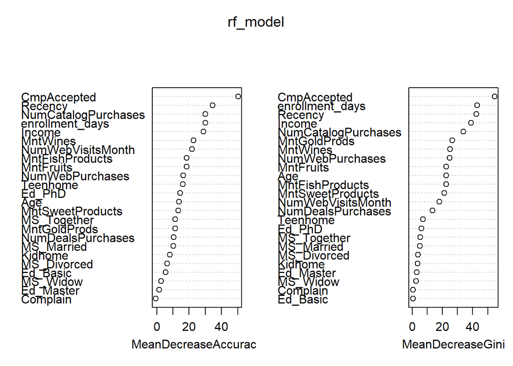

```r
varImpPlot(rf_model)
```